# shm-102-introduction

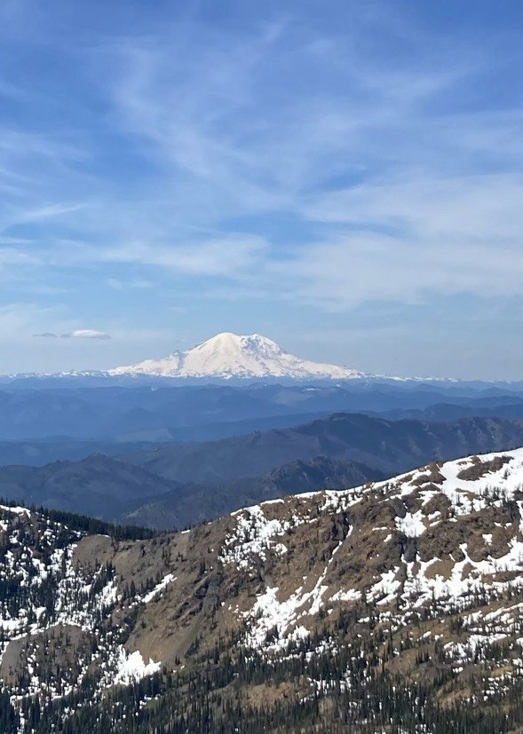

Mount Rainier, Washington. Photograph by Yoni Rodriguez, 2022.

## SHM 102: Occupational Health

### Introduction to Occupational Health

**Lecture 01 · Fall 2026**

Yoni Rodriguez  
Engineering Technologies, Safety, and Construction  
Central Washington University  
Yoni.Rodriguez@cwu.edu

# What is Occupational Health?

## Before We Define It…

Let’s start with what you already think.

### Poll Everywhere

1. *What comes to mind when you hear the term “occupational health”?*
2. *In your own words, how would you define occupational health?*

There is no expectation that you know the formal definition yet. Give me your best answer.

[figure not shown]

### A working definition

“*Occupational and environmental health is the study and prevention of health problems caused or influenced by the environments where people work, live, and interact*.” - **Centers for Disease Control and Prevention (CDC)**

## Where does Occupational Health occur?

- Do you get exposed on your way to work?
- Does the community nearby get exposed?
- Do you take the exposures home?

## Why is Occupational Health important?

- Does this impact my health?
- Does this impact the health of my family?
- Does this impact the health of my community?

# Current News

[figure not shown]

*The New York Times*, August 13, 2026.  
[Read the article →](https://www.nytimes.com/2026/08/13/science/paraquat-pesticide-parkinsons-california.html)

# Where is paraquat used?

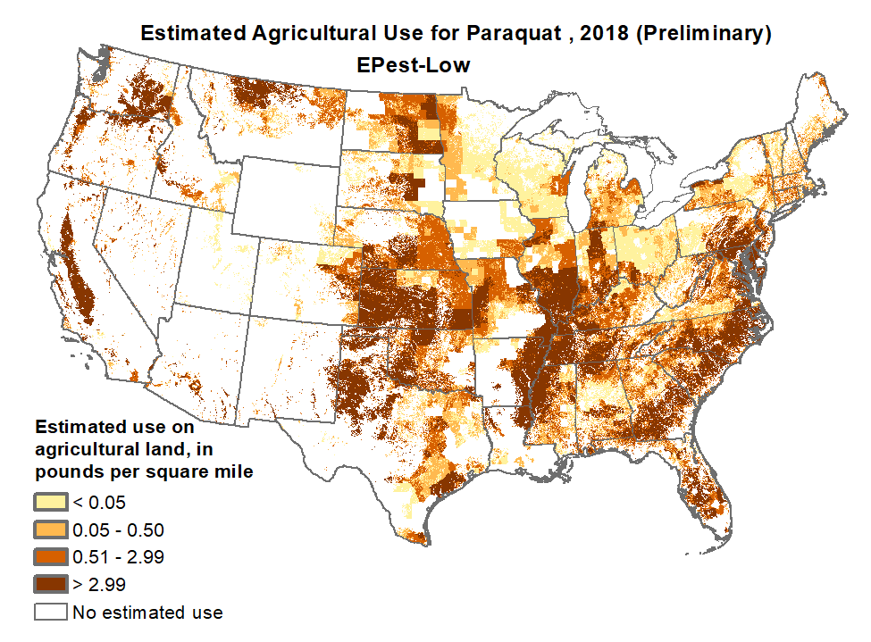

Estimated agricultural use of paraquat in the United States, 2018.

*Source: U.S. Geological Survey.*  
[Explore paraquat use map →](https://water.usgs.gov/nawqa/pnsp/usage/maps/show_map.php?year=2018&map=PARAQUAT&hilo=L&disp=Paraquat)

# Who is exposed?

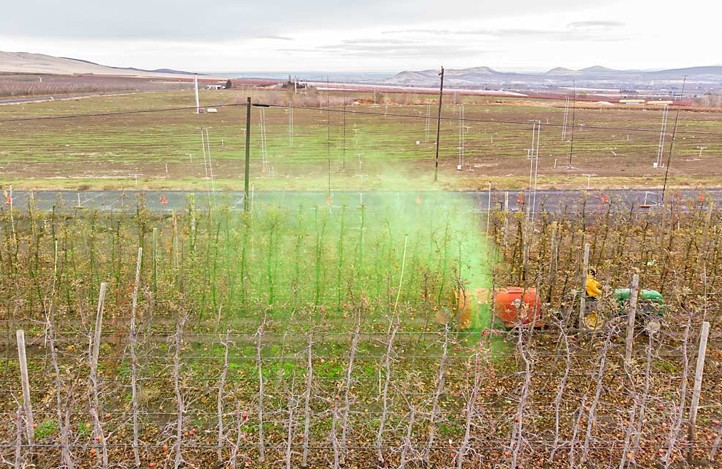

Pesticide application with fluorescent tracer.

## Where was the applicator exposed?

[figure not shown]

Fluorescent tracer visible on the applicator’s face following pesticide application.

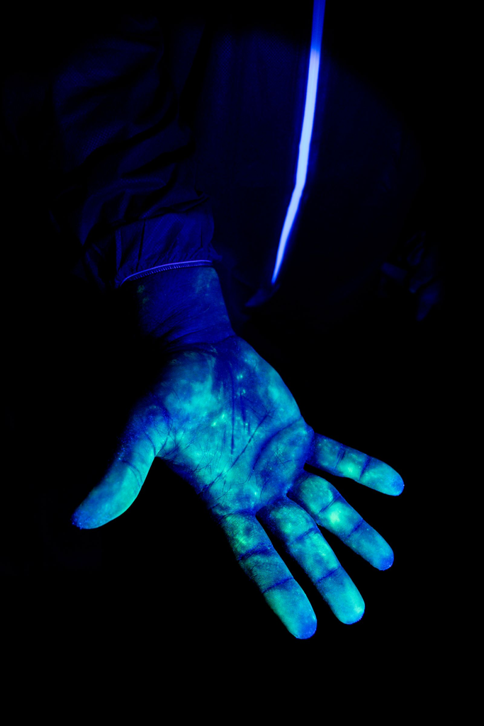

Fluorescent tracer visible on the applicator’s hand following pesticide application.

**Photos:** Cesar Ramirez and Matteo Vijarro.  
**Research supported by:** [Pacific Northwest Agricultural Safety and Health Center (PNASH)](https://pnash.deohs.washington.edu/), University of Washington.

# Is the applicator the only person exposed?

## Pesticide drift in Washington State

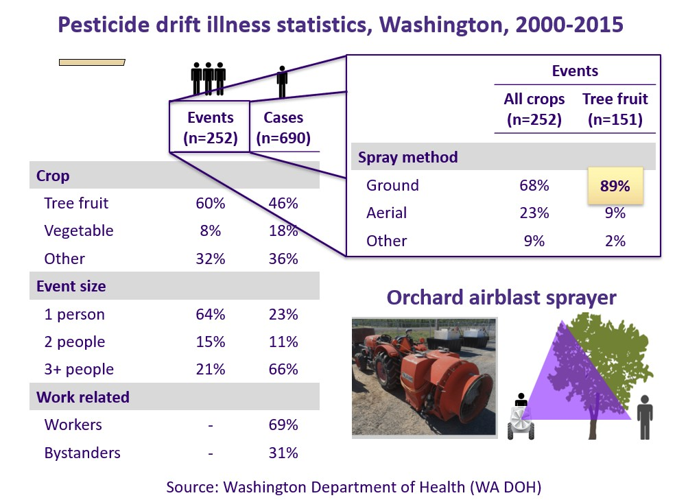

*Source: Kasner et al. (2021), Environmental Health.*  
[View study on PubMed →](https://pubmed.ncbi.nlm.nih.gov/33722241/)

# What happens when exposure occurs?

## Paraquat: acute toxicity

[figure not shown]

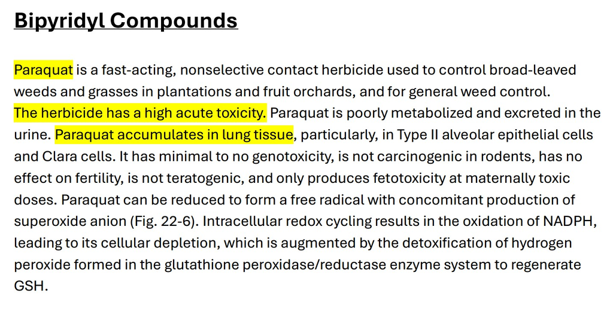

*Source: Costa (2021), “Toxic Effects of Pesticides,” in Casarett & Doull’s Essentials of Toxicology.*  
[View textbook chapter →](https://accesspharmacy-mhmedical-com.offcampus.lib.washington.edu/content.aspx?bookid=3000&sectionid=252315470)

## What can severe acute exposure do?

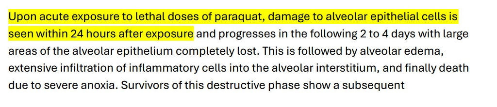

*Source: Costa (2021), “Toxic Effects of Pesticides,” in Casarett & Doull’s Essentials of Toxicology.*  
[View textbook chapter →](https://accesspharmacy-mhmedical-com.offcampus.lib.washington.edu/content.aspx?bookid=3000&sectionid=252315470)

## What about long-term health?

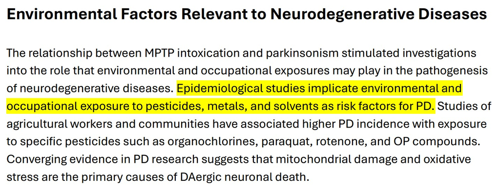

*Source: Moser et al. (2021), “Toxic Responses of the Nervous System,” in Casarett & Doull’s Essentials of Toxicology.*  
[View textbook chapter →](https://accesspharmacy-mhmedical-com.offcampus.lib.washington.edu/content.aspx?bookid=3000&sectionid=252314425)

# What did we just do?

### We identified a **hazard**

**Paraquat**

### ↓

### We asked **where it is used**

**Agricultural workplaces and environments**

### ↓

### We identified **who can be exposed**

**Applicators → Coworkers → Bystanders → Communities**

### ↓

### We examined **how people are exposed**

**Dermal contact → Inhalation → Ingestion**

### ↓

### We considered **what happens after exposure**

**Toxicity → Health effects → Health risks**

## This is Occupational Health

# How to Apply Occupational Health

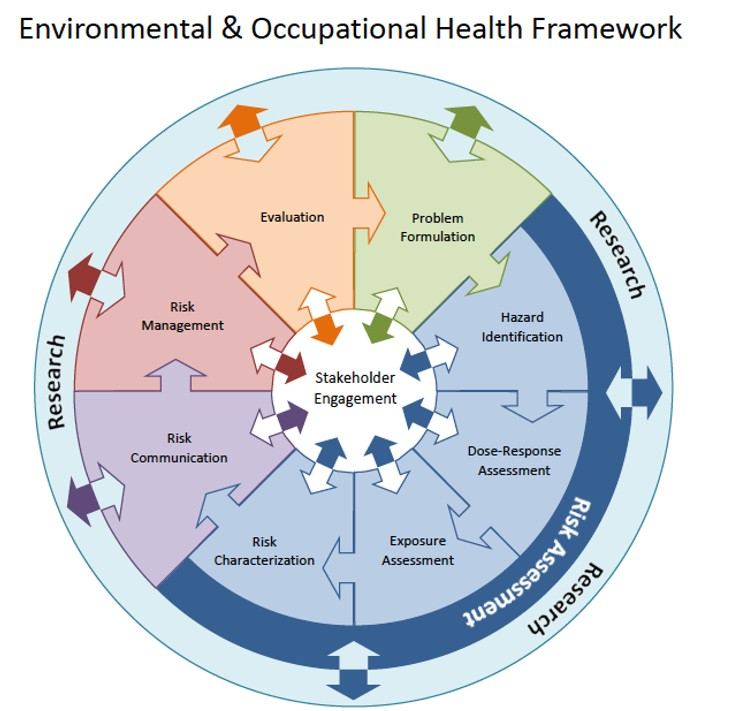

*Source: University of Washington Department of Environmental & Occupational Health Sciences.*  
[Explore the ENV H 501 course framework →](https://deohs.washington.edu/sites/default/files/course-materials/2023_AUT_ENV_H_501.pdf)

## How do we control exposure?

### If a hazard can affect health, What can we do about it?

# Hierarchy of Controls

[figure not shown]

*Source: National Institute for Occupational Safety and Health (NIOSH).*  
[Explore the Hierarchy of Controls →](https://www.cdc.gov/niosh/hierarchy-of-controls/about/index.html)

# Apply it to our case

## How could we reduce pesticide exposure?

### Where would you intervene?

## Apply the Hierarchy of Controls

Take a couple of minutes to discuss with your classmates.

Using the **Hierarchy of Controls**, consider:

1. **What could we do to reduce or prevent pesticide exposure?**
2. **Where in the hierarchy would your intervention fall?**
3. **Why would your approach reduce exposure?**

When you’re ready, submit your responses through Poll Everywhere.

[figure not shown]

# What could prevention look like?

### Can we measure environmental conditions and use that information before exposure occurs?

# Measuring the environment

[figure not shown]

Washington State University AgWeatherNet weather station.

*Source: Washington State University AgWeatherNet.*  
[Explore AgWeatherNet →](https://weather.wsu.edu/login)

# From measurement to prediction

[figure not shown]

Short-term wind speed forecast using AgWeatherNet observations.

*Source: Rodriguez, Y. — Exploring Wind Ramping as a Determinant of Pesticide Drift, University of Washington DEOHS.*  
[View research project →](https://deohs.washington.edu/student-research/yoni-rodriguez)

# Where does this fit in the Hierarchy of Controls?

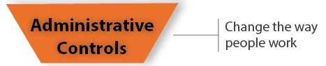

## Administrative Control

**Forecast → Alert → Delay or reschedule application**

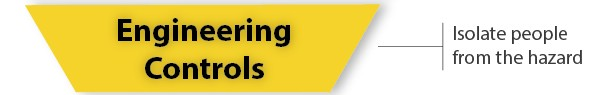

## Engineering Control

**Forecast → Equipment responds → Modify or stop application**

*Source: National Institute for Occupational Safety and Health (NIOSH).*  
[Explore the Hierarchy of Controls →](https://www.cdc.gov/niosh/hierarchy-of-controls/about/index.html)

# What will we explore?

## Five broad categories of occupational hazards

**Occupational Health**

Chemical

Physical

Biological

Ergonomic

Psychosocial

# What will we learn in this course

| What we do | Why it matters |
| --- | --- |
| **Identify Hazards** | Recognize conditions or agents that could cause harm so future or recurring exposures can be prevented. |
| **Measure Hazards** | Collect accurate information about the hazard and its source so we can determine where and when exposure is occurring. |
| **Assess Hazards** | Understand the hazard, its source, the exposure context, and its significance within a specific workplace or setting. |
| **Control Hazards** | Develop effective interventions that eliminate or reduce the hazard or exposure using the **Hierarchy of Controls**. |

### Understand exposure. Prevent harm.

# Key Terms

### These are the terms I expect you to know from today’s lecture for the mid-term.

| Term | What should you know? |
| --- | --- |
| **Occupational health** | Understanding and preventing health problems related to work and work environments |
| **Hazard** | Something with the potential to cause harm to human health |
| **Exposure** | Contact between a person and a hazard |
| **Exposure route** | How a hazard enters or contacts the body: inhalation, ingestion, or dermal contact |
| **Acute health effect** | A health effect occurring relatively soon after exposure |
| **Chronic health effect** | A health effect developing or persisting over a longer period |
| **Hierarchy of Controls** | A framework for selecting ways to prevent or reduce exposure (*know the hierarchy*) |
| **Administrative control** | Changing how or when people work |
| **Engineering control** | Isolating people from a hazard |

# Make your flashcards

### Copy → Paste → Study

Copy the terms below to make your own **Anki or Quizlet** flashcards.

**Anki:** Save as a `.txt` file → Import → Select **Semicolon** as the field separator.

```
Occupational health;Understanding and preventing health problems related to work and work environments
Hazard;Something with the potential to cause harm to human health
Exposure;Contact between a person and a hazard
Exposure route;How a hazard enters or contacts the body: inhalation, ingestion, or dermal contact
Acute health effect;A health effect occurring relatively soon after exposure
Chronic health effect;A health effect developing or persisting over a longer period
Hierarchy of Controls;A framework for selecting ways to prevent or reduce exposure. Know the order: elimination → substitution → engineering controls → administrative controls → PPE
Administrative control;Changing how or when people work
Engineering control;Isolating people from a hazard
```

### Copyright & Use

**SHM 102: Occupational Health**  
© 2026 Yoni Rodriguez

Except where otherwise noted, original course materials are licensed under the Creative Commons Attribution-NonCommercial 4.0 International License (CC BY-NC 4.0).

Third-party materials remain subject to their respective copyright and licensing terms.